# Examen Final de Análisis y Diseños de Experimentos

Jaime Gomez Marin

#### 1.- En un artículo de Solid State Technology (“Diseño ortogonal para optimización de procesos y su aplicación en el grabado químico con plasma”) se describe la aplicación de diseños factoriales en el desarrollo de un proceso de grabado químico con nitruros en un dispositivo de grabado químico con plasma para una sola oblea El proceso usa C2F6 como gas de reacción. Cuatro factores son de interés: el entrehierro ánodo-cátodo (A), la presión en la cámara del reactor (B), el flujo del gas C2F6 (C) y la potencia aplicada al cátodo (D). La respuesta de interés es la rapidez de grabado para el nitruro de silicio. Se corre una sola réplica de un diseño 24; los datos se muestran enseguida:

[output not shown]

y=c(550,669,604,650,633,642,601,635,1037,749,1052,868,1075,860,1063,759)

#### a).Estimar los efectos de los factores y obtenga una gráfica de probabilidad normal de los efectos estimados de estos factores. ¿Que efectos parecen ser grande? ( 6 puntos)

```r
#
y=c(550,669,604,650,633,642,601,635,1037,749,1052,868,1075,860,1063,759)

#
A <- rep(c(rep(-1, 1) , rep(1, 1)) , 8)
B <- rep(c(rep(-1, 2) , rep(1, 2)) , 4)
C <- rep(c(rep(-1, 4) , rep(1, 4)) , 2)
D <- rep(c(rep(-1, 8) , rep(1, 8)) , 1)

#
printmat("y ",y)
```

```
## [1] "y :  [1]  550  669  604  650  633  642  601  635 1037  749 1052  868 1075  860"
## [2] "y : [15] 1063  759"
```

```r
printmat("A ",A)
```

```
## [1] "A :  [1] -1  1 -1  1 -1  1 -1  1 -1  1 -1  1 -1  1 -1  1"
```

```r
printmat("B ",B)
```

```
## [1] "B :  [1] -1 -1  1  1 -1 -1  1  1 -1 -1  1  1 -1 -1  1  1"
```

```r
printmat("C ",C)
```

```
## [1] "C :  [1] -1 -1 -1 -1  1  1  1  1 -1 -1 -1 -1  1  1  1  1"
```

```r
printmat("D ",D)
```

```
## [1] "D :  [1] -1 -1 -1 -1 -1 -1 -1 -1  1  1  1  1  1  1  1  1"
```

```r
mod <- lm(y~A*B*C*D)
Estimados <- 2*coefficients(mod)[-1]  # Se retira la columna del intercepto
# Estimados
round(Estimados, 0)
```

```
##       A       B       C       D     A:B     A:C     B:C     A:D     B:D
##     -98       2      11     310      -4     -21     -40    -150       3
##     C:D   A:B:C   A:B:D   A:C:D   B:C:D A:B:C:D
##       2     -12       8       9     -22     -36
```

Hay que buscar los estimados que mas aportan al modelo

```r
data.frame(round(Estimados, 0))
```

|  | round.Estimados..0. |
| --- | --- |
| A | -98 |
| B | 2 |
| C | 11 |
| D | 310 |
| A:B | -4 |
| A:C | -21 |
| B:C | -40 |
| A:D | -150 |
| B:D | 3 |
| C:D | 2 |

[output cut: 5 more lines]

Quienes mas aportan son: 1,4,6,7,8,14,15

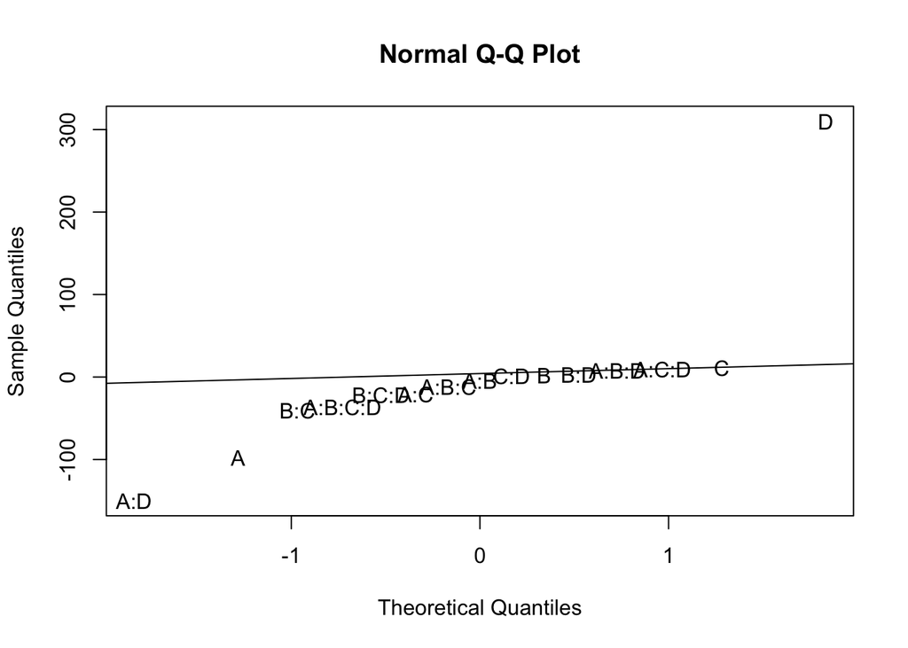

```r
qq <- qqnorm(Estimados,type="n")
Efectos <- names(Estimados)
text(qq$x, qq$y, labels = Efectos)
Estimados1 <- Estimados[-c(1,4,6,7,8,14,15)] # SON LOS VALORES QUE MAS APORTAN AL MODELO
# Estimados1 <- Estimados
qqline(Estimados1)
```

De la grafica se puede apreciar que los siguiente efectos son los mas grandes en orden de influencia:

- D : La potencia aplicada al cátodo
- A*D : El entrehierro ánodo-cátodo y la potencia aplicada al cátodo
- A : El entrehierro ánodo-cátodo
- B*C : La presión en la cámara del reacto y el flujo del gas C2F6

#### b).- Realice el análisis de varianza para confirmar los resultados obtenidos en (a), Obtenga la ecuación de regresión estimada (4 puntos)

```r
# Con la información de los efectos detectados en el apartado anterior procedemos a  construimos nuestro modelo
mod1  <- lm(y ~ A + D + A*D + B*C + A*C + A*B*C + B*C*D )
```

```r
# Realizamos nuestro analisis de varianza
anva1 <- aov(mod1)
summary(anva1)
```

```
##             Df Sum Sq Mean Sq F value   Pr(>F)
## A            1  38318   38318  19.510 0.021540 *
## D            1 384090  384090 195.559 0.000792 ***
## B            1     18      18   0.009 0.929648
## C            1    495     495   0.252 0.650161
## A:D          1  89850   89850  45.747 0.006603 **
## B:C          1   6440    6440   3.279 0.167858
## A:C          1   1785    1785   0.909 0.410748
## A:B          1     68      68   0.035 0.864199
## D:B          1     39      39   0.020 0.896786
## D:C          1     11      11   0.005 0.946156
## A:B:C        1    564     564   0.287 0.629211
## D:B:C        1   1871    1871   0.952 0.401085
## Residuals    3   5892    1964
## ---
## Signif. codes:  0 '***' 0.001 '**' 0.01 '*' 0.05 '.' 0.1 ' ' 1
```

$$y = \beta_0 + \beta_1x_1 +\beta_2x_2 + \beta_3x_3 + \beta_4x_4 + \beta_{14}x_1x_4 + \beta_{23}x_2x_3 + \beta_{13}x_1x_3 + \beta_{12}x_1x_2 + \beta_{42}x_4x_2 +\beta_{43}x_4x_3 + \beta_{123}x_1x_2x_3 + \beta_{423}x_4x_2x_3$$
Donde:

$x_i$ = 1, si el nivel del factor de i se encuentra alto

i = 1 , representa el factor de A

i = 2 , representa el factor de B

i = 3 , representa el factor de C

i = 4 , representa el factor de D

De los cuatro factores son de interés: el entrehierro ánodo-cátodo (A), la presión en la cámara del reactor (B), el flujo del gas C2F6 (C) y la potencia aplicada al cátodo (D) se ha llegado a las siguientes conclusiones

a).- Los efectos que tiene influenciencia altamente muy significativa sobre la rapidez de grabado para el nitruro de silicio son:

- D = La potencia aplicada al catodo

b).- Los efectos que tiene influenciencia muy significativa sobre la rapidez de grabado para el nitruro de silicio son:

- entre A = El entrehierro ánodo-cátodo con D = La potencia aplicada al catodo

c).- Los efectos que tiene influenciencia significativa sobre la rapidez de grabado para el nitruro de silicio son:

- A = El entrehierro ánodo-cátodo

d).- No se encontró diferencias significativas

- B = la presión en la cámara del reactor
- C = el flujo del gas C2F6
- entre B = la presión en la cámara del reactor con C = el flujo del gas C2F6
- entre A = El entrehierro ánodo-cátodo con C = el flujo del gas C2F6
- entre A = El entrehierro ánodo-cátodo con B = la presión en la cámara del reactor
- entre D = La potencia aplicada al catodo con C = el flujo del gas C2F6
- entre A = El entrehierro ánodo-cátodo , B = la presión en la cámara del reactor y C = el flujo del gas C2F6
- entre D = La potencia aplicada al catodo , B = la presión en la cámara del reactor y C = el flujo del gas C2F6

```r
# Obtenemos los parametros
coefficients(mod1)
```

```
## (Intercept)           A           D           B           C         A:D
##    777.9375    -48.9375    154.9375      1.0625      5.5625    -74.9375
##         B:C         A:C         A:B         D:B         D:C       A:B:C
##    -20.0625    -10.5625     -2.0625      1.5625      0.8125     -5.9375
##       D:B:C
##    -10.8125
```

Del analisis de varianza se detecto que los efectos mas importantes son de A, D y A:D

```
## hat values (leverages) are all = 0.8125
##  and there are no factor predictors; no plot no. 5
```

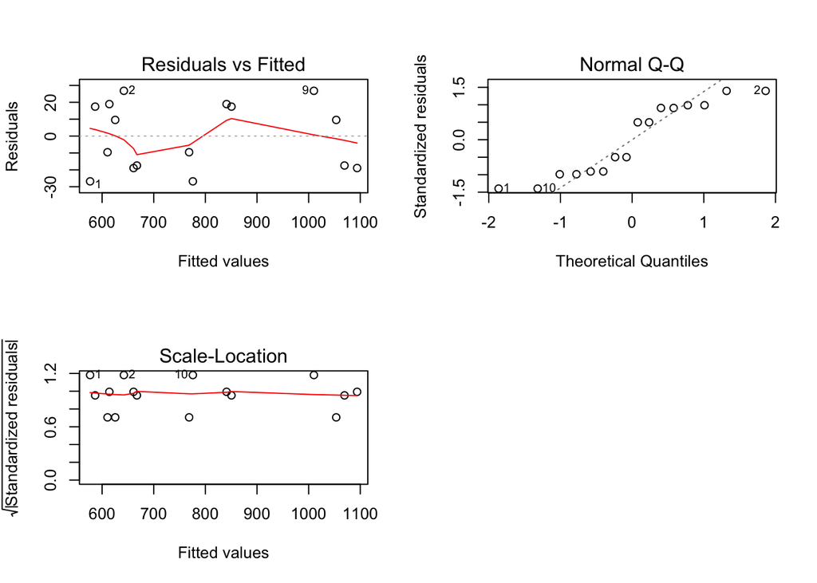

```r
par(mfrow=c(2,2))
plot(mod1)
```

```r
ri1<-rstandard(mod1)
shapiro.test(ri1)
```

```
##
##  Shapiro-Wilk normality test
##
## data:  ri1
## W = 0.87299, p-value = 0.03022
```

```r
library(car)
ncvTest(mod1)
```

```
## Non-constant Variance Score Test
## Variance formula: ~ fitted.values
## Chisquare = 0.005323703, Df = 1, p = 0.94183
```

##Analisis Factorial 2x4

#### 2.)- Un teléfono inteligente es un teléfono móvil que ofrece una capacidad de cómputo y conectividad más avanzadas que un “teléfono con funciones” básica contemporáneo. Los datos siguientes son las calificaciones de seis teléfonos inteligentes de cada uno de los cuatro proveedores, tres de los cuales cuestan $ 150 o más, otros tres cuestan menos de $ 150. Las calificaciones tienen un valor máximo de 100 y un mínimo de 0.

[output not shown]

Datos en archivo teléfono.txt #### a).- Realice el Análisis de Variancia, Pruebe la hipótesis correspondientes y de las conclusiones y recomendaciones correspondiente. (4 puntos)

```r
telefono<-read.table("telefono.txt",T)
str(telefono)
```

```
## 'data.frame':    24 obs. of  3 variables:
##  $ calificaciones: int  76 74 69 69 67 64 74 69 68 69 ...
##  $ costo         : Factor w/ 2 levels "a1","a2": 1 1 1 2 2 2 1 1 1 2 ...
##  $ proveedor     : Factor w/ 4 levels "b1","b2","b3",..: 1 1 1 1 1 1 2 2 2 2 ...
```

```r
Calificación<-telefono[,1]
Costo<-as.factor(telefono[,2])
Proveedor<-as.factor(telefono[,3])
mod<-lm(Calificación~Costo*Proveedor)
anva<-aov(mod)
summary(anva)
```

```
##                 Df Sum Sq Mean Sq F value  Pr(>F)
## Costo            1  92.04   92.04  13.893 0.00183 **
## Proveedor        3  81.12   27.04   4.082 0.02490 *
## Costo:Proveedor  3  33.46   11.15   1.683 0.21053
## Residuals       16 106.00    6.63
## ---
## Signif. codes:  0 '***' 0.001 '**' 0.01 '*' 0.05 '.' 0.1 ' ' 1
```

## Hipotesis del efecto principal de Costo

Se rechaza la $H_0$, a un nivel de significacion del 1%, se ha encontrado suficientes evidencia estadistica para rechazar la $H_0$ de que las categorias de los Costos tenga un efecto significativo sobre la Calificación del teléfono.Por lo tanto, se puede aceptar de que existe diferencias significativas entre al menos dos categorias de costos de teléfono tienen un efecto significativo sobre su calificación

## Hipotesis del efecto principal de Proveedor

Se rechaza la $H_0$, a un nivel de significacion del 5%, se ha encontrado suficientes evidencia estadistica para rechazar la $H_0$ de que las proveedores tenga un efecto significativo sobre la calificación del teléfono.Por lo tanto, se puede aceptar de que existe diferencias significativas entre al menos dos proveedores tienen un efecto significativo sobre la calificación del teléfono.

## Hipotesis del efecto de interacción entre el Costo y el Proveedor

$H_0$ : $(\alpha * \beta )_ = 0$ , para i,j = 1,2,3

$H_1$ : al menos dos $(\alpha * \beta ) != 0$ , para i,j = 1,2,3

Se acepta $H_0$, a un nivel de significacion del 10%, no se ha encontrado suficiente evidencia estadistica para rechazar la $H_0$ ,es decir que no existe ning'un efecto de la interaci'on entre la categoria del costo y el proveedor influyan sobre la calificación del teléfono.

#### b).- Teniendo en cuenta los resultados obtenido en (a), realice la prueba de Tukey correspondiente

(6 puntos)

De la parte a, se ha visto que la categoria de costo y los proveedores tiene efecto sobre la calificación del teléfono, se procedera a realizar la prueba de Tukey para la Cada uno de ellos

```r
library(multcomp)
```

```r
tHSD <- TukeyHSD(anva)
summary(tHSD)
```

```
##                 Length Class  Mode
## Costo             4    -none- numeric
## Proveedor        24    -none- numeric
## Costo:Proveedor 112    -none- numeric
```

```r
tHSD
```

```
##   Tukey multiple comparisons of means
##     95% family-wise confidence level
##
## Fit: aov(formula = mod)
##
## $Costo
##            diff       lwr       upr     p adj
## a2-a1 -3.916667 -6.144249 -1.689084 0.0018334
##
## $Proveedor
##            diff        lwr      upr     p adj
## b2-b1 -2.500000 -6.7516077 1.751608 0.3643388
## b3-b1  1.166667 -3.0849410 5.418274 0.8601187
## b4-b1  2.500000 -1.7516077 6.751608 0.3643388
## b3-b2  3.666667 -0.5849410 7.918274 0.1039730
## b4-b2  5.000000  0.7483923 9.251608 0.0185696
## b4-b3  1.333333 -2.9182743 5.584941 0.8063964
##
## $`Costo:Proveedor`
##                   diff         lwr        upr     p adj
## a2:b1-a1:b1 -6.3333333 -13.6093432  0.9426765 0.1129895
## a1:b2-a1:b1 -2.6666667  -9.9426765  4.6093432 0.8976115
## a2:b2-a1:b1 -8.6666667 -15.9426765 -1.3906568 0.0140595
## a1:b3-a1:b1 -1.6666667  -8.9426765  5.6093432 0.9911124
## a2:b3-a1:b1 -2.3333333  -9.6093432  4.9426765 0.9451981
## a1:b4-a1:b1  0.6666667  -6.6093432  7.9426765 0.9999756
## a2:b4-a1:b1 -2.0000000  -9.2760099  5.2760099 0.9752592
## a1:b2-a2:b1  3.6666667  -3.6093432 10.9426765 0.6614247
## a2:b2-a2:b1 -2.3333333  -9.6093432  4.9426765 0.9451981
## a1:b3-a2:b1  4.6666667  -2.6093432 11.9426765 0.3896498
## a2:b3-a2:b1  4.0000000  -3.2760099 11.2760099 0.5673822
## a1:b4-a2:b1  7.0000000  -0.2760099 14.2760099 0.0638225
## a2:b4-a2:b1  4.3333333  -2.9426765 11.6093432 0.4752993
## a2:b2-a1:b2 -6.0000000 -13.2760099  1.2760099 0.1484555
## a1:b3-a1:b2  1.0000000  -6.2760099  8.2760099 0.9996326
## a2:b3-a1:b2  0.3333333  -6.9426765  7.6093432 0.9999998
## a1:b4-a1:b2  3.3333333  -3.9426765 10.6093432 0.7517157
## a2:b4-a1:b2  0.6666667  -6.6093432  7.9426765 0.9999756
## a1:b3-a2:b2  7.0000000  -0.2760099 14.2760099 0.0638225
## a2:b3-a2:b2  6.3333333  -0.9426765 13.6093432 0.1129895
## a1:b4-a2:b2  9.3333333   2.0573235 16.6093432 0.0075749
## a2:b4-a2:b2  6.6666667  -0.6093432 13.9426765 0.0852319
## a2:b3-a1:b3 -0.6666667  -7.9426765  6.6093432 0.9999756
## a1:b4-a1:b3  2.3333333  -4.9426765  9.6093432 0.9451981
## a2:b4-a1:b3 -0.3333333  -7.6093432  6.9426765 0.9999998
## a1:b4-a2:b3  3.0000000  -4.2760099 10.2760099 0.8321663
## a2:b4-a2:b3  0.3333333  -6.9426765  7.6093432 0.9999998
## a2:b4-a1:b4 -2.6666667  -9.9426765  4.6093432 0.8976115
```

$Costo diff lwr upr p adj a2-a1 -3.916667 -6.144249 -1.689084 0.0018334

$Proveedor diff lwr upr p adj

b4-b2 5.000000 0.7483923 9.251608 0.0185696

Para los otros casos no existe diferencias significativa